# Bike Share Case Study - 3 - Analysis

This analysis notebook will record the analysis of differences in bike share usage between members and casual riders.

Let’s look again at the numbers of rides by members and by casual riders.

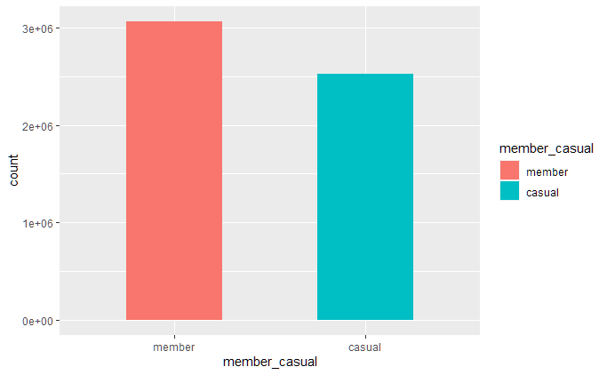

```r
bike_share %>%
  ggplot(mapping = aes(x = member_casual)) +
  geom_bar(mapping = aes(fill = member_casual), width = 0.5)
```

In 2021 there were about 3 million rides by members, and about 2.5 million rides by casual riders.

# Analysis - Time distribution

Let’s look the time distributions of rides for the two types of users. We’ll look at ride counts per quarter and per month.

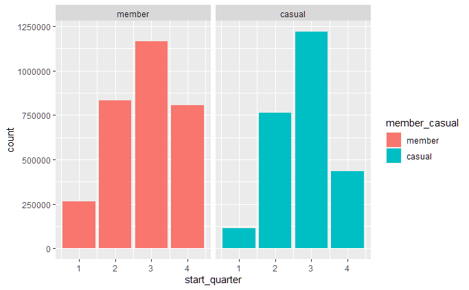

```r
bike_share %>%
  ggplot(mapping = aes(x = start_quarter)) +
  geom_bar(mapping = aes(fill = member_casual)) +
  facet_wrap(~ member_casual)
```

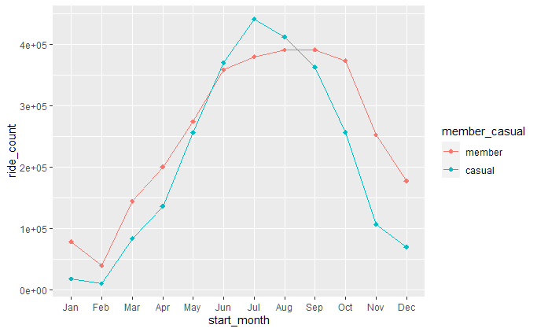

```r
bike_share %>%
  group_by(start_month, member_casual) %>%
  summarize(ride_count = n(), .groups = "keep") %>%
  ggplot(mapping = aes(x = start_month, y = ride_count)) +
  geom_line(mapping = aes(color = member_casual, group = member_casual)) +
  geom_point(mapping = aes(color = member_casual), size = 2, shape = 18)
```

There are more rides by casual riders than by members in the months June, July, and August. The numbers of rides by casual riders peak more sharply than the numbers of rides by members in the months May to October, and they fall off more in the colder months.

Let’s see how the percentages of rides by the two groups changed over time.

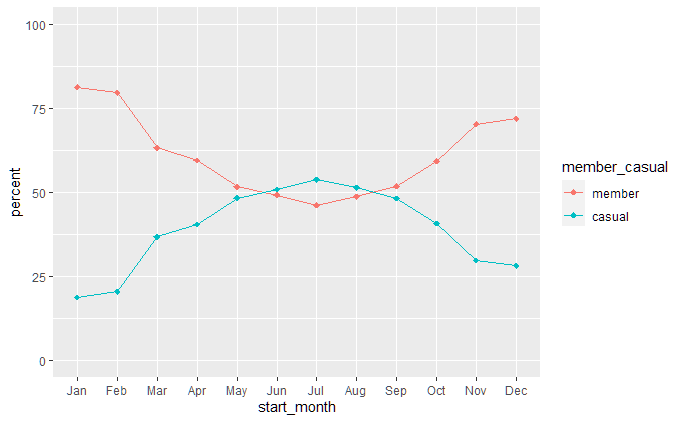

```r
bike_share %>%
  group_by(start_month, member_casual) %>%
  summarize(n = n(), .groups = "keep") %>%
  group_by(start_month) %>%
  mutate(percent = 100 * n / sum(n)) %>%
  ggplot(mapping = aes(x = start_month, y = percent, group = member_casual)) +
  geom_line(mapping = aes(color = member_casual)) +
  geom_point(mapping = aes(color = member_casual), size = 2, shape = 18) +
  coord_cartesian(ylim = c(0, 100))
```

The percentages are nearly the same from May to September, but in other months there’s a significant difference in usage. In the colder months there are two or three times as many rides by members than by casual users.

Let’s look at rides per week.

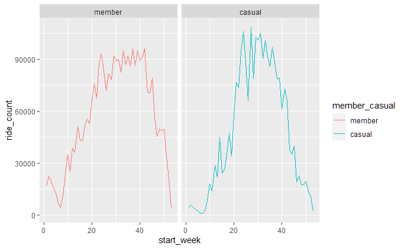

```r
bike_share %>%
  group_by(start_week, member_casual) %>%
  summarize(ride_count = n(), .groups = "keep") %>%
  ggplot(mapping = aes(x = start_week, y = ride_count)) +
  geom_line(mapping = aes(color = member_casual)) +
  facet_wrap(~ member_casual)
```

There appears to be more variability in the ride counts per week for casual riders. Let’s look at the weekly excess of rides for members (orange) and casual riders (blue).

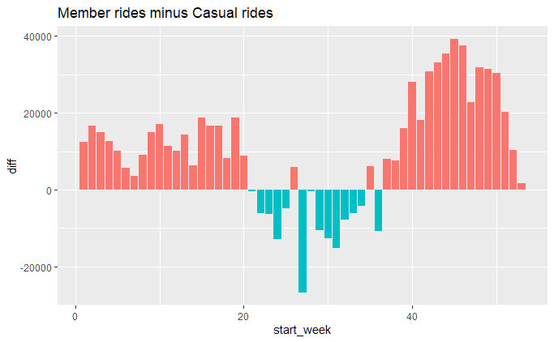

```r
bike_share %>%
  group_by(start_week) %>%
  summarize(
    diff = sum(member_casual == "member") - sum(member_casual == "casual"),
    .groups = "keep"
  ) %>%
  ggplot(mapping = aes(x = start_week, y = diff, fill = diff < 0)) +
  geom_col() +
  theme(legend.position = "none") +
  ggtitle(label = "Member rides minus Casual rides")
```

Even though there are more rides by casual riders than by members in the summer months, the difference varies a lot from week to week. And a few weeks in the summer have more rides by members.

Let’s look at the percentage of rides by members on each day of the month as a check on data quality.

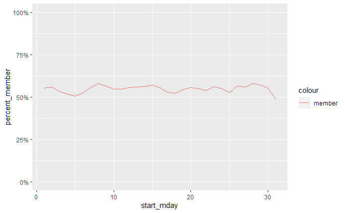

```r
bike_share %>%
  group_by(start_mday) %>%
  summarize(percent_member = mean(member_casual == "member")) %>%
  ggplot(mapping = aes(x = start_mday, y = percent_member)) +
  geom_line(aes(color = "member")) +
  coord_cartesian(ylim = c(0, 1)) +
  scale_y_continuous(labels = scales::percent)
```

The percentage of rides by members is as expected, given the overall member/casual ride ratio of 6 to 5.

Now let’s look at rides by day of the week.

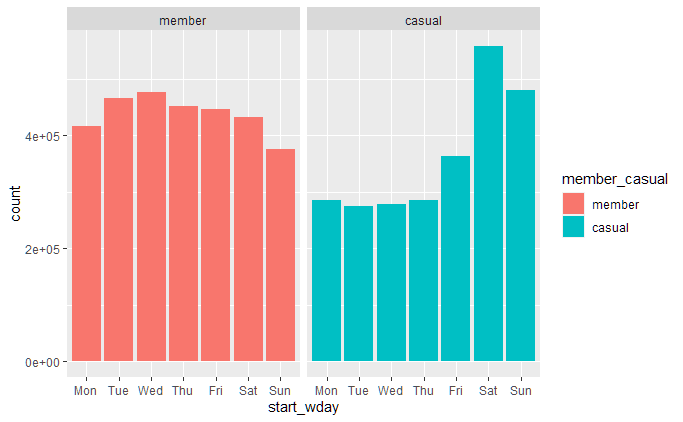

```r
bike_share %>%
  ggplot(mapping = aes(x = start_wday)) +
  geom_bar(mapping = aes(fill = member_casual)) +
  facet_wrap(~ member_casual)
```

Counts of rides by members show less variability by day of the week, and are generally lowest on Sunday. But rides by casual riders increase significantly on weekends.

Let’s look at ride percentage by user type and day of the week, across quarters. First we’ll look at rides by members.

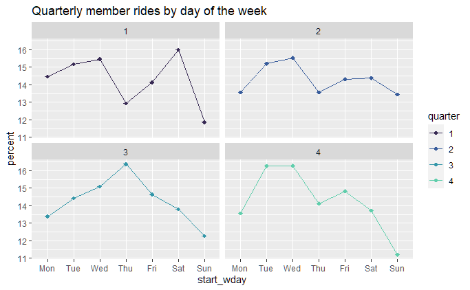

```r
bike_share %>%
  filter(member_casual == "member") %>%
  mutate(quarter = factor(start_quarter)) %>%
  group_by(quarter, start_wday) %>%
  summarize(n = n(), .groups = "keep") %>%
  group_by(quarter) %>%
  mutate(percent = 100 * n / sum(n)) %>%
  ggplot(mapping = aes(x = start_wday, y = percent, group = quarter)) +
  geom_line(mapping = aes(color = quarter)) +
  geom_point(mapping = aes(color = quarter), size = 2, shape = 18) +
  scale_color_viridis_d(option = "mako", begin = 0.2, end = 0.8) +
  facet_wrap(~ quarter) +
  ggtitle(label = "Quarterly member rides by day of the week")
```

There doesn’t seem to be a strong pattern for members. Sunday has the lowest percentage of rides in each quarter. Since quarters have different numbers of each day of the week, we should look at this monthly, and use only the first 28 days of the month so that each period has equal numbers of each day of the week.

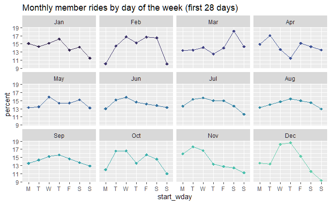

```r
bike_share %>%
  filter(member_casual == "member" & start_mday < 29) %>%
  group_by(start_month, start_wday) %>%
  summarize(n = n(), .groups = "keep") %>%
  group_by(start_month) %>%
  mutate(percent = 100 * n / sum(n)) %>%
  ggplot(mapping = aes(x = start_wday, y = percent, group = start_month)) +
  geom_line(mapping = aes(color = start_month)) +
  geom_point(mapping = aes(color = start_month), size = 2, shape = 18) +
  scale_color_viridis_d(option = "mako", begin = 0.2, end = 0.8) +
  facet_wrap(~ start_month) +
  ggtitle(label = "Monthly member rides by day of the week (first 28 days)") +
  scale_x_discrete(labels = substr(levels(bike_share$start_wday), 1, 1)) +
  theme(legend.position = "none")
```

There still doesn’t appear to be a strong pattern. But during the high ride volume months of June through September the highest percentages of rides are usually on Wednesday or Thursday, and the lowest on Monday or Sunday.

Let’s look at the same plots for casual riders.

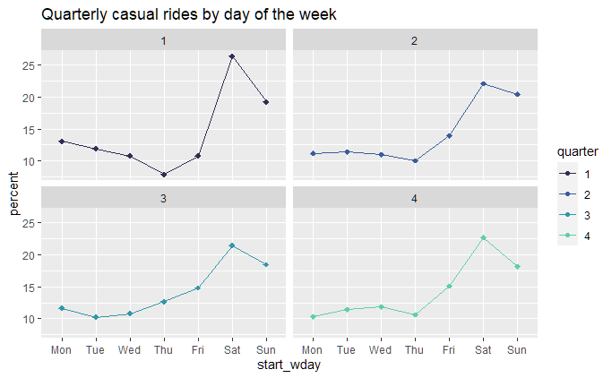

```r
bike_share %>%
  filter(member_casual == "casual") %>%
  mutate(quarter = factor(start_quarter)) %>%
  group_by(quarter, start_wday) %>%
  summarize(n = n(), .groups = "keep") %>%
  group_by(quarter) %>%
  mutate(percent = 100 * n / sum(n)) %>%
  ggplot(mapping = aes(x = start_wday, y = percent, group = quarter)) +
  geom_line(mapping = aes(color = quarter)) +
  geom_point(mapping = aes(color = quarter), size = 2, shape = 18) +
  scale_color_viridis_d(option = "mako", begin = 0.2, end = 0.8) +
  facet_wrap(~ quarter) +
  ggtitle(label = "Quarterly casual rides by day of the week")
```

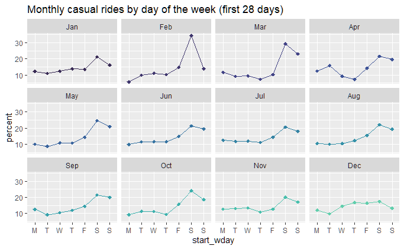

```r
bike_share %>%
  filter(member_casual == "casual" & start_mday < 29) %>%
  group_by(start_month, start_wday) %>%
  summarize(n = n(), .groups = "keep") %>%
  group_by(start_month) %>%
  mutate(percent = 100 * n / sum(n)) %>%
  ggplot(mapping = aes(x = start_wday, y = percent, group = start_month)) +
  geom_line(mapping = aes(color = start_month)) +
  geom_point(mapping = aes(color = start_month), size = 2, shape = 18) +
  scale_color_viridis_d(option = "mako", begin = 0.2, end = 0.8) +
  facet_wrap(~ start_month) +
  ggtitle(label = "Monthly casual rides by day of the week (first 28 days)") +
  scale_x_discrete(labels = substr(levels(bike_share$start_wday), 1, 1)) +
  theme(legend.position = "none")
```

Casual riders have a strong pattern of increased rides on weekends, with Saturday having the highest percentage of rides in each period and Sunday usually having the second highest.

For each month, let’s compare the percentages of rides by the two groups of users on each day of the week.

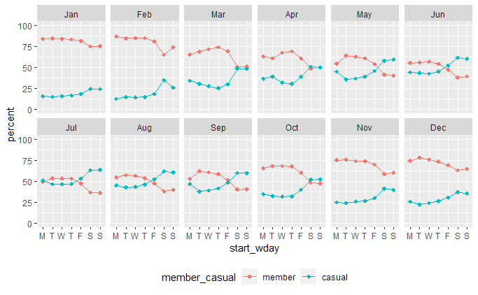

```r
 bike_share %>%
  group_by(start_month, start_wday, member_casual) %>%
  summarize(n = n(), .groups = "keep") %>%
  group_by(start_month, start_wday) %>%
  mutate(percent = 100 * n / sum(n)) %>%
  ggplot(mapping = aes(x = start_wday, y = percent, group = member_casual)) +
  geom_line(mapping = aes(color = member_casual)) +
  geom_point(mapping = aes(color = member_casual), size = 2, shape = 18) +
  facet_wrap(~ start_month, nrow = 2) +
  scale_x_discrete(labels = substr(levels(bike_share$start_wday), 1, 1)) +
  coord_cartesian(ylim = c(0, 100)) +
  theme(legend.position = "bottom")
```

In nearly all months the rides by members outnumber those by casual riders on Mondays, Tuesdays, Wednesdays, and Thursdays. From April to October the rides by casual riders outnumber those by members on Saturdays and Sundays, and often on Fridays also.

Let’s look at plots to compare the two groups by the hour at which the rides begin.

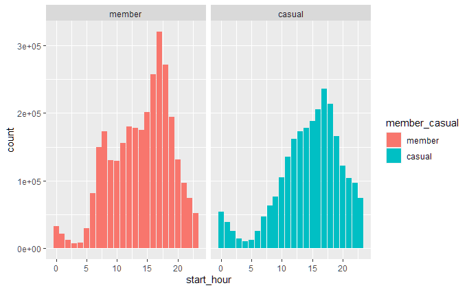

```r
bike_share %>%
  ggplot(mapping = aes(x = start_hour)) +
  geom_bar(mapping = aes(fill = member_casual)) +
  facet_wrap(~ member_casual)
```

Let’s break it down by quarters.

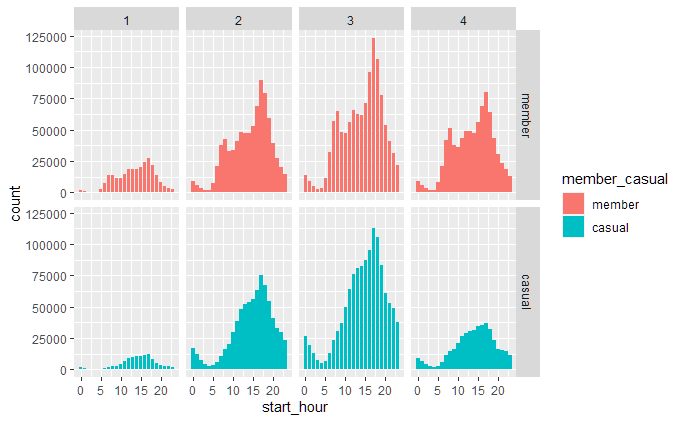

```r
bike_share %>%
  ggplot(mapping = aes(x = start_hour)) +
  geom_bar(mapping = aes(fill = member_casual)) +
  facet_grid(member_casual ~ start_quarter)
```

The pattern for members has a small peak of rides around 8 a.m and a larger peak around 5 p.m. For casual riders there’s no morning peak, but there’s a peak around 5 p.m.

Let’s look at ride percentage by rider type and hour of the day, across quarters and months. First we’ll look at rides by members.

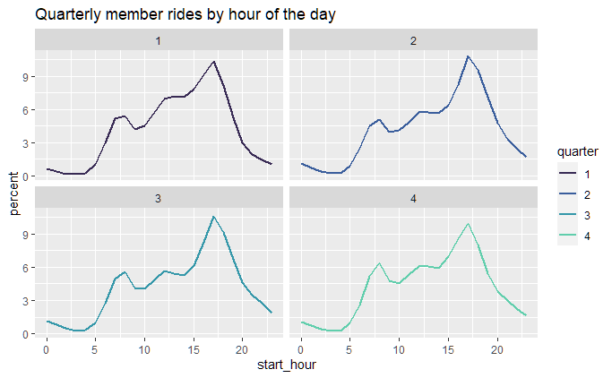

```r
bike_share %>%
  filter(member_casual == "member") %>%
  mutate(quarter = factor(start_quarter)) %>%
  group_by(quarter, start_hour) %>%
  summarize(n = n(), .groups = "keep") %>%
  group_by(quarter) %>%
  mutate(percent = 100 * n / sum(n)) %>%
  ggplot(mapping = aes(x = start_hour, y = percent, group = quarter)) +
  geom_line(mapping = aes(color = quarter), size = 1) +
  scale_color_viridis_d(option = "mako", begin = 0.2, end = 0.8) +
  facet_wrap(~ quarter) +
  ggtitle(label = "Quarterly member rides by hour of the day")
```

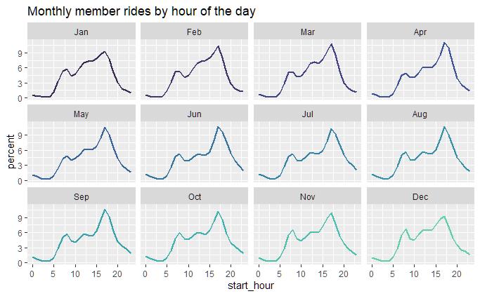

```r
bike_share %>%
  filter(member_casual == "member") %>%
  group_by(start_month, start_hour) %>%
  summarize(n = n(), .groups = "keep") %>%
  group_by(start_month) %>%
  mutate(percent = 100 * n / sum(n)) %>%
  ggplot(mapping = aes(x = start_hour, y = percent, group = start_month)) +
  geom_line(mapping = aes(color = start_month), size = 1) +
  scale_color_viridis_d(option = "mako", begin = 0.2, end = 0.8) +
  facet_wrap(~ start_month) +
  ggtitle(label = "Monthly member rides by hour of the day") +
  theme(legend.position = "none")
```

For members there’s a stable distribution for the percentage of rides by hour, having a small peak around 8 a.m. and a larger peak around 5 p.m.

Now we’ll look at the casual riders.

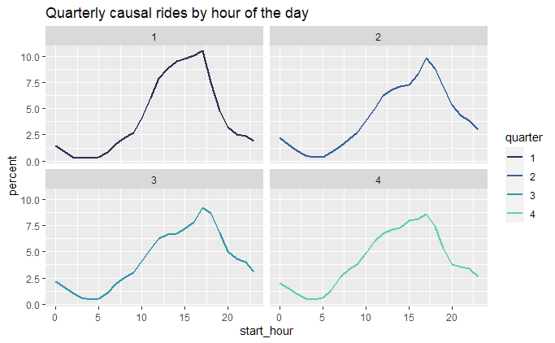

```r
bike_share %>%
  filter(member_casual == "casual") %>%
  mutate(quarter = factor(start_quarter)) %>%
  group_by(quarter, start_hour) %>%
  summarize(n = n(), .groups = "keep") %>%
  group_by(quarter) %>%
  mutate(percent = 100 * n / sum(n)) %>%
  ggplot(mapping = aes(x = start_hour, y = percent, group = quarter)) +
  geom_line(mapping = aes(color = quarter), size = 1) +
  scale_color_viridis_d(option = "mako", begin = 0.2, end = 0.8) +
  facet_wrap(~ quarter) +
  ggtitle(label = "Quarterly causal rides by hour of the day")
```

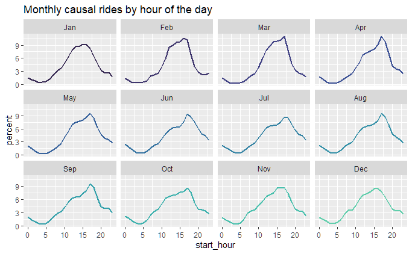

```r
bike_share %>%
  filter(member_casual == "casual") %>%
  group_by(start_month, start_hour) %>%
  summarize(n = n(), .groups = "keep") %>%
  group_by(start_month) %>%
  mutate(percent = 100 * n / sum(n)) %>%
  ggplot(mapping = aes(x = start_hour, y = percent, group = start_month)) +
  geom_line(mapping = aes(color = start_month), size = 1) +
  scale_color_viridis_d(option = "mako", begin = 0.2, end = 0.8) +
  facet_wrap(~ start_month) +
  ggtitle(label = "Monthly causal rides by hour of the day") +
  theme(legend.position = "none")
```

For casual riders there’s also a stable distribution for percentage of rides by hour. It doesn’t have the peak around 8 a.m. The percentage rises fairly steadily from a low around 4 a.m. to a peak at 5 p.m. There’s also a higher percentage of rides in the late evening and early morning hours.

Now we’ll compare the two groups of users by percentages of rides per hour across all months.

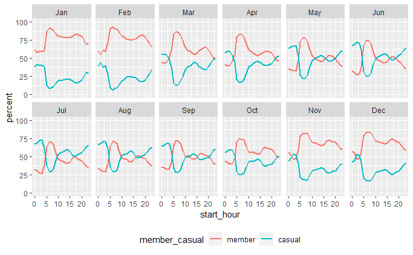

```r
 bike_share %>%
  group_by(start_month, start_hour, member_casual) %>%
  summarize(n = n(), .groups = "keep") %>%
  group_by(start_month, start_hour) %>%
  mutate(percent = 100 * n / sum(n)) %>%
  ggplot(mapping = aes(x = start_hour, y = percent, group = member_casual)) +
  geom_line(mapping = aes(color = member_casual), size = 1) +
  facet_wrap(~ start_month, nrow = 2) +
  coord_cartesian(ylim = c(0, 100)) +
  theme(legend.position = "bottom")
```

In most months, casual rides outnumbered member rides in the early morning before 5 a.m. Then from 5 a.m. to 10 a.m. there were nearly always two to three times more rides by members than by casual riders. From March to October the percentages of rides by both groups were similar between 10 a.m. and 3 p.m., with casual riders taking more rides in the months May to September. In the warmer months there were more casual rides in the evenings.

Let’s look at percentage of rides by day of the week and by hour of the day within the member user group. We’ll look at each quarter.

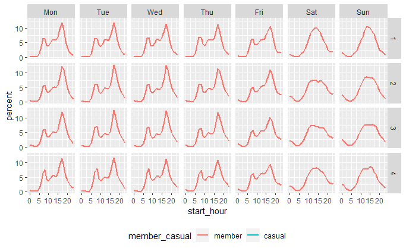

```r
 bike_share %>%
  filter(member_casual == "member") %>%
  group_by(start_quarter, start_wday, start_hour, member_casual) %>%
  summarize(n = n(), .groups = "keep") %>%
  group_by(start_quarter, start_wday, member_casual) %>%
  mutate(percent = 100 * n / sum(n)) %>%
  ggplot(mapping = aes(x = start_hour, y = percent)) +
  geom_line(mapping = aes(color = member_casual), size = 1) +
  scale_color_discrete(drop = FALSE) +
  facet_grid(start_quarter ~ start_wday) +
  theme(legend.position = "bottom")
```

Now we’ll look at the same for casual riders.

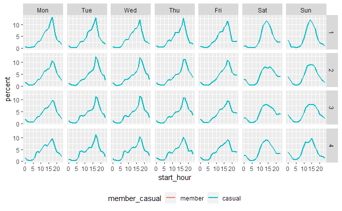

```r
 bike_share %>%
  filter(member_casual == "casual") %>%
  group_by(start_quarter, start_wday, start_hour, member_casual) %>%
  summarize(n = n(), .groups = "keep") %>%
  group_by(start_quarter, start_wday, member_casual) %>%
  mutate(percent = 100 * n / sum(n)) %>%
  ggplot(mapping = aes(x = start_hour, y = percent)) +
  geom_line(mapping = aes(color = member_casual), size = 1) +
  scale_color_discrete(drop = FALSE) +
  facet_grid(start_quarter ~ start_wday) +
  theme(legend.position = "bottom")
```

The plots for Saturday and Sunday look similar for both groups. Let’s plot both groups together to see where the differences lie.

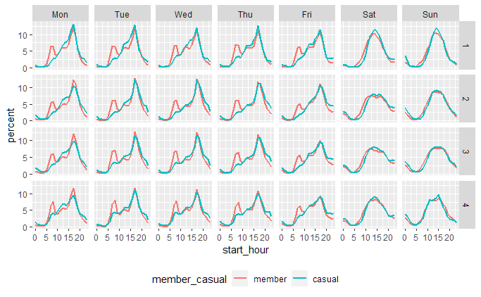

```r
 bike_share %>%
  group_by(start_quarter, start_wday, start_hour, member_casual) %>%
  summarize(n = n(), .groups = "keep") %>%
  group_by(start_quarter, start_wday, member_casual) %>%
  mutate(percent = 100 * n / sum(n)) %>%
  ggplot(mapping = aes(x = start_hour, y = percent)) +
  geom_line(mapping = aes(color = member_casual), size = 1) +
  facet_grid(start_quarter ~ start_wday) +
  theme(legend.position = "bottom")
```

This comparison shows that on Saturdays and Sundays, the distributions of rides by hour of the day are very similar for both user types. The significant differences in the bike use percentage by hour are limited to week days, in particular the peak of hourly percentage for member rides centered around 8 a.m., and less markedly the greater percentages of rides by casual users in the mid-afternoon and late evening.

Let’s compare the relative proportions of members and causal riders by hour and day of the week.

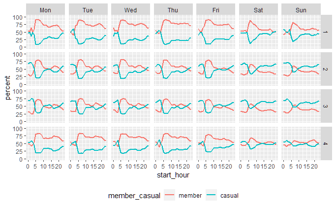

```r
 bike_share %>%
  group_by(start_quarter, start_hour, start_wday, member_casual) %>%
  summarize(n = n(), .groups = "keep") %>%
  group_by(start_quarter, start_hour, start_wday) %>%
  mutate(percent = 100 * n / sum(n)) %>%
  ggplot(mapping = aes(x = start_hour, y = percent, group = member_casual)) +
  geom_line(mapping = aes(color = member_casual), size = 1) +
  facet_grid(start_quarter ~ start_wday) +
  coord_cartesian(ylim = c(0, 100)) +
  theme(legend.position = "bottom")
```

The curves for each user type and day of the week don’t change much in shape across quarters, especially in the high volume second and third quarters. But the relative heights of the curves come closer together in the second and third quarters when there are more casual riders. These plots show that rides by members nearly always outnumber those by casual riders, except on weekends in the second and third quarters, and in the late night and early morning hours of week days in those same quarters.

# Analysis - Rideable_type

Let’s look ride counts by user type and bike type.

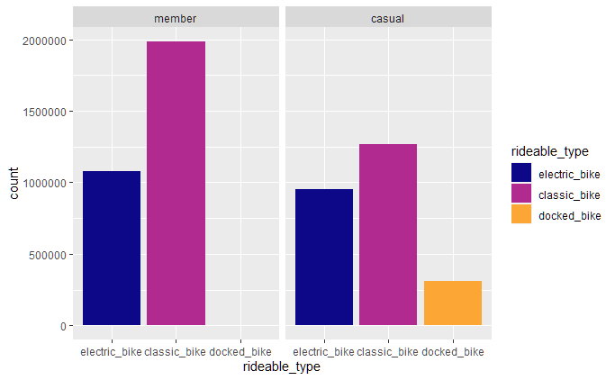

```r
bike_share %>%
  ggplot(mapping = aes(x = rideable_type)) +
  geom_bar(mapping = aes(fill = rideable_type)) +
  scale_fill_viridis_d(option = "plasma", end = 0.8, drop = FALSE) +
  facet_wrap(~ member_casual)
```

Both groups use classic bikes more often than electric bikes. It appears that only casual riders use the docked bikes, but we’ll check that.

```r
bike_share %>%
  filter(rideable_type == "docked_bike") %>%
  group_by(member_casual) %>%
  count()
```

| member_casual | n |
| --- | --- |
| member | 1 |
| casual | 312179 |

There was only one docked bike ride by a member.

Instead of ride counts, let’s look at the percentages of rides on each type of bike within the two groups.

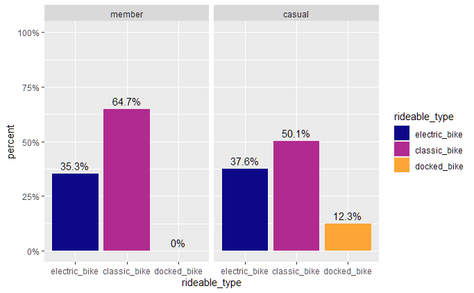

```r
bike_share %>%
  group_by(member_casual, rideable_type) %>%
  summarize(n = n(), .groups = "keep") %>%
  group_by(member_casual) %>%
  mutate(
    percent = n / sum(n),
    label = paste(as.character(round(100 * percent, 1)), "%", sep = "")
  ) %>%
  ggplot(mapping = aes(x = rideable_type, y = percent)) +
  geom_col(mapping = aes(fill = rideable_type)) +
  scale_fill_viridis_d(option = "plasma", end = 0.8, drop = FALSE) +
  geom_text(mapping = aes(label = label), vjust = -0.5) +
  scale_y_continuous(labels = scales::percent) +
  coord_cartesian(ylim = c(0, 1)) +
  facet_wrap(~ member_casual)
```

Overall, both groups use electric bikes at the nearly the same rate. Among non-electric casual rides the ratio of classic to docked bikes is about 4 to 1.

Let’s see how these percentages change during the year. First we’ll look at rides by members.

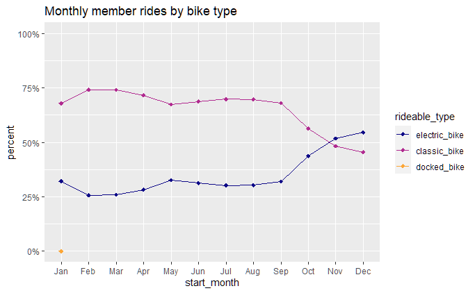

```r
bike_share %>%
  filter(member_casual == "member") %>%
  group_by(rideable_type, start_month) %>%
  summarize(ride_count = n(), .groups = "keep") %>%
  group_by(start_month) %>%
  mutate(percent = ride_count / sum(ride_count)) %>%
  ggplot(mapping = aes(x = start_month, y = percent, group = rideable_type)) +
  geom_line(mapping = aes(color = rideable_type)) +
  geom_point(mapping = aes(color = rideable_type), size = 2, shape = 18) +
  scale_y_continuous(labels = scales::percent) +
  scale_color_viridis_d(option = "plasma", end = 0.8, drop = FALSE) +
  coord_cartesian(ylim = c(0, 1)) +
  ggtitle(label = "Monthly member rides by bike type")
```

For members the relative percentages of rides on electric and classic bikes are stable until the last three months of the year, during which the percentage of rides on electric bikes increases and overtakes that of rides on classic bikes.

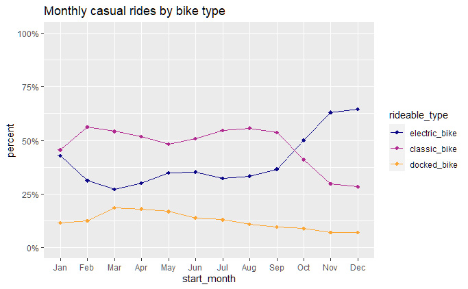

```r
bike_share %>%
  filter(member_casual == "casual") %>%
  group_by(rideable_type, start_month) %>%
  summarize(ride_count = n(), .groups = "keep") %>%
  group_by(start_month) %>%
  mutate(percent = ride_count / sum(ride_count)) %>%
  ggplot(mapping = aes(x = start_month, y = percent, group = rideable_type)) +
  geom_line(mapping = aes(color = rideable_type)) +
  geom_point(mapping = aes(color = rideable_type), size = 2, shape = 18) +
  scale_y_continuous(labels = scales::percent) +
  scale_color_viridis_d(option = "plasma", end = 0.8, drop = FALSE) +
  coord_cartesian(ylim = c(0, 1)) +
  ggtitle(label = "Monthly casual rides by bike type")
```

Rides by casual riders show more variability in choice of bike type in the first nine months of the year, but starting in October there’s the same shift from classic to electric bikes that was seen among rides by members. Also, from March to December there’s a gradual decrease in the percentage of rides on docked bikes. These changes in use of bike types could be due to a change in the availability of the different bike types, or in the cost of rides on different types of bikes. More information than what’s in the data would be needed to determine why these changes in use of bike types happened.

Let’s look at monthly percentages of electric bike rides by user type.

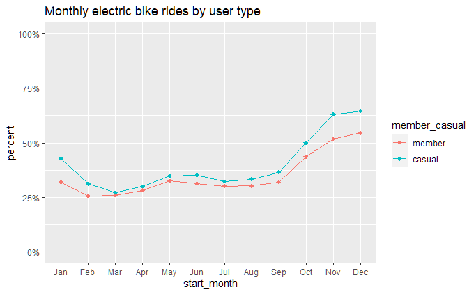

```r
bike_share %>%
  group_by(start_month, rideable_type, member_casual) %>%
  summarize(ride_count = n(), .groups = "keep") %>%
  group_by(start_month, member_casual) %>%
  mutate(percent = ride_count / sum(ride_count)) %>%
  filter(rideable_type == "electric_bike") %>%
  ggplot(mapping = aes(x = start_month, y = percent, group = member_casual)) +
  geom_line(mapping = aes(color = member_casual)) +
  geom_point(mapping = aes(color = member_casual), size = 2, shape = 18) +
  scale_y_continuous(labels = scales::percent) +
  coord_cartesian(ylim = c(0, 1)) +
  ggtitle(label = "Monthly electric bike rides by user type")
```

Whatever caused the increase in the use of electric bikes at the end of the year, it appears to have had the same affect on both user groups. There doesn’t appear to be an any significant difference in preference for electric bikes between the two user groups.